# HW4_STA578

Jiaming Chen

10/5/2017

```r
library(caret)
library(MASS)     # lda function used by caret
library(dplyr)    # data frame manipulations
```

```r
library(ggplot2)  # plotting
library(ISLR)
library(STA578)
```

## Question 5

5.a and b

```r
library(gridExtra)
```

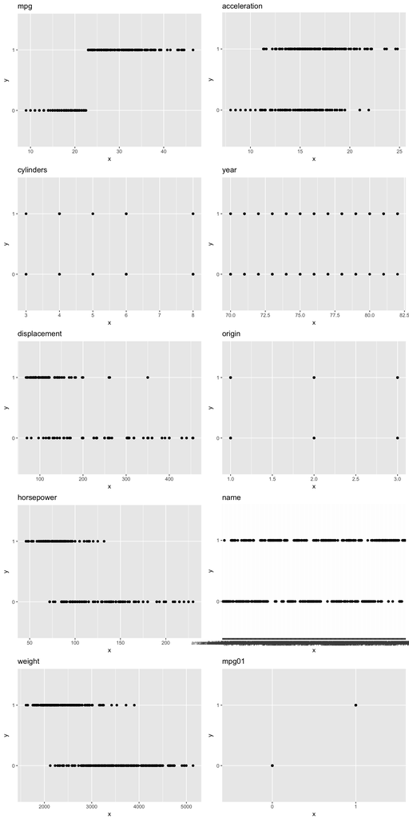

```r
data('Auto', package='ISLR')
Auto <- Auto %>%
  mutate(mpg01 = factor(1* (mpg > median(mpg)) ))


plots <- list()
i <- 1
for(col_ in  names(Auto)){

  df <- data.frame(
    x = Auto[[col_]],
    y = Auto$mpg01
  )
  plots[[col_]] <- ggplot(df,aes(x=x, y=y)) +
  geom_point() +
  ggtitle(col_)
  i <- i+1
}

multiplot(plotlist = plots,ncol=2)
```

5.c,d and e,f

```r
Auto.Train <- Auto %>% sample_frac(.5)
Auto.Test  <- setdiff(Auto, Auto.Train)

# performing LDA
lda.fit = lda(mpg01 ~ cylinders + weight + acceleration + horsepower, data = Auto.Train)
lda.pred = predict(lda.fit, Auto.Test)
# test error of LDA
mean(lda.pred$class != Auto.Test$mpg01)
```

```
## [1] 0.1020408
```

```r
# performing QDA
qda.fit = qda(mpg01 ~ cylinders + weight + acceleration + horsepower, data = Auto.Train)
qda.pred = predict(qda.fit, Auto.Test)
# test error of QDA
mean(qda.pred$class != Auto.Test$mpg01)
```

```
## [1] 0.1122449
```

```r
# performing logistic regression
glm.fit = glm(mpg01 ~ cylinders + weight + displacement + horsepower, data = Auto.Train,
    family = binomial)
glm.probs = predict(glm.fit, Auto.Test, type = "response")
yhat = ifelse(glm.probs > .5, 1, 0)
# test error of Logistic Regression
mean(yhat != Auto.Test$mpg01)
```

```
## [1] 0.122449
```

5.g Testing on different k values for KNN

```r
# performing KNN
model <- train(mpg01 ~ cylinders + weight + displacement + horsepower, data=Auto.Test,
               method='knn', tuneGrid=data.frame(k=3))
knn.pred <- predict(model, newdata=Auto.Test)
# test error of KNN (k=3)
mean(knn.pred != Auto.Test$mpg01)
```

```
## [1] 0.07142857
```

```r
# performing KNN
model <- train(mpg01 ~ cylinders + weight + displacement + horsepower, data=Auto.Test,
               method='knn', tuneGrid=data.frame(k=10))
knn.pred <- predict(model, newdata=Auto.Test)
# test error of KNN (k=10)
mean(knn.pred != Auto.Test$mpg01)
```

```
## [1] 0.1020408
```

```r
# performing KNN
model <- train(mpg01 ~ cylinders + weight + displacement + horsepower, data=Auto.Test,
               method='knn', tuneGrid=data.frame(k=5))
knn.pred <- predict(model, newdata=Auto.Test)
# test error of KNN (k=5)
mean(knn.pred != Auto.Test$mpg01)
```

```
## [1] 0.09183673
```

## Question 6

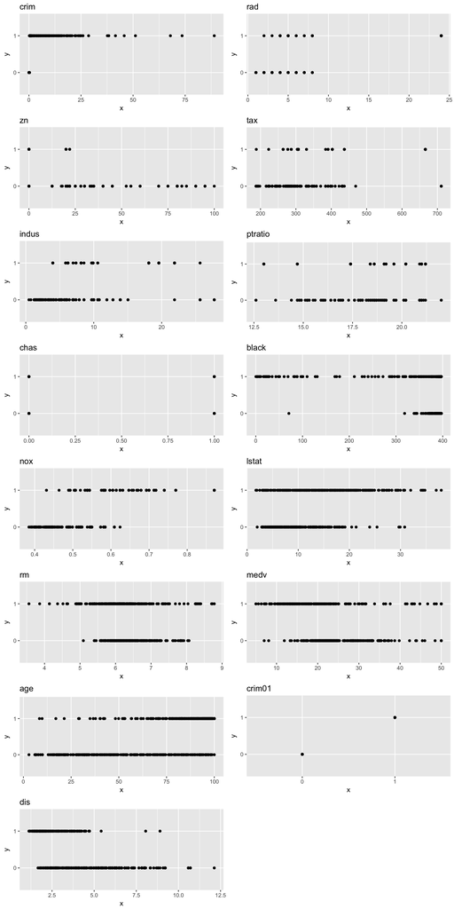

```r
# adding column crime01
data('Boston', package='MASS')
Boston <- Boston %>%
  mutate(crim01 = factor(1* (crim > median(crim)) ))


plots <- list()
i <- 1
for(col_ in  names(Boston)){

  df <- data.frame(
    x = Boston[[col_]],
    y = Boston$crim01
  )
  plots[[col_]] <- ggplot(df,aes(x=x, y=y)) +
  geom_point() +
  ggtitle(col_)
  i <- i+1
}

multiplot(plotlist = plots,ncol=2)
```

From the scatterplots, we can see that attributes ‘indus’, ‘nox’, ‘dis’, ‘black’ and ‘medv’ are the variables correlated to ‘crim’. We’ll use these attributes to predict whether criminal is above median or not.

```r
# split the data into various subset
Train1 <- Boston %>% sample_frac(.5)
Test1  <- setdiff(Boston, Train1)

Train2 <- Boston %>% sample_frac(.5)
Test2  <- setdiff(Boston, Train2)

Train3 <- Boston %>% sample_frac(.5)
Test3  <- setdiff(Boston, Train3)

Train4 <- Boston %>% sample_frac(.5)
Test4  <- setdiff(Boston, Train4)

# performing logistic regression on Train1
glm.fit = glm(crim01 ~ indus + nox + dis + black + medv, data = Train1,
    family = binomial)
glm.probs = predict(glm.fit, Test1, type = "response")
yhat = ifelse(glm.probs > .5, 1, 0)
# test error of Logistic Regression
mean(yhat != Test1$crim01)
```

```
## [1] 0.173913
```

```r
# performing logistic regression on Training set 2
glm.fit = glm(crim01 ~ indus + nox + dis + black + medv, data = Train2,
    family = binomial)
glm.probs = predict(glm.fit, Test2, type = "response")
yhat = ifelse(glm.probs > .5, 1, 0)
# test error of Logistic Regression
mean(yhat != Test2$crim01)
```

```
## [1] 0.1857708
```

```r
# performing LDA
lda.fit = lda(crim01 ~ indus + nox + dis + black + medv, data = Train2)
lda.pred = predict(lda.fit, Test2)
# test error of LDA
mean(lda.pred$class != Test2$crim01)
```

```
## [1] 0.2055336
```

```r
# performing LDA
lda.fit = lda(crim01 ~ indus + nox + dis + black + medv, data = Train3)
lda.pred = predict(lda.fit, Test3)
# test error of LDA
mean(lda.pred$class != Test3$crim01)
```

```
## [1] 0.1620553
```

We can find that the performance of LDA, Logistic Regression varies between different training set. Different training set will result in models which have different test errors. Now we want to verify this idea using KNN

```r
# performing KNN
model <- train(crim01 ~ indus + nox + dis + black + medv, data = Train3,
               method='knn', tuneGrid=data.frame(k=5))
knn.pred <- predict(model, newdata=Test3)
# test error of KNN (k=5)
mean(knn.pred != Test3$crim01)
```

```
## [1] 0.173913
```

```r
# performing KNN
model <- train(crim01 ~ indus + nox + dis + black + medv, data = Train3,
               method='knn', tuneGrid=data.frame(k=10))
knn.pred <- predict(model, newdata=Test3)
# test error of KNN (k=10)
mean(knn.pred != Test3$crim01)
```

```
## [1] 0.1581028
```

```r
# performing KNN
model <- train(crim01 ~ indus + nox + dis + black + medv, data = Train3,
               method='knn', tuneGrid=data.frame(k=3))
knn.pred <- predict(model, newdata=Test3)
# test error of KNN (k=3)
mean(knn.pred != Test3$crim01)
```

```
## [1] 0.1462451
```

It looks like k=3 gives a better result. Next step is to test on different subset with k=3

```r
# performing KNN
model <- train(crim01 ~ indus + nox + dis + black + medv, data = Train4,
               method='knn', tuneGrid=data.frame(k=3))
knn.pred <- predict(model, newdata=Test4)
# test error of KNN (k=3)
mean(knn.pred != Test4$crim01)
```

```
## [1] 0.1383399
```

With this training set, we got a better performance (lower test error rate). The conclusion is that different subsets will produce different model and different performance even if the classification methods are the same